# PA1_template

Ricardo Andrade

5/4/2020

## 1. Data procesing

We will first read the csv file to load it to the R enviroment, save it in the data variable and do a little a general exploring to see the type of data and its summary:

```r
data<-read.csv("C:/Users/Ricardo/Desktop/Coursera/Data Science Specialization/Reproducible Research/Week 2/Project/activity.csv",stringsAsFactors = F)
str(data)
```

```
## 'data.frame':    17568 obs. of  3 variables:
##  $ steps   : int  NA NA NA NA NA NA NA NA NA NA ...
##  $ date    : chr  "2012-10-01" "2012-10-01" "2012-10-01" "2012-10-01" ...
##  $ interval: int  0 5 10 15 20 25 30 35 40 45 ...
```

```r
summary(data)
```

```
##      steps            date              interval
##  Min.   :  0.00   Length:17568       Min.   :   0.0
##  1st Qu.:  0.00   Class :character   1st Qu.: 588.8
##  Median :  0.00   Mode  :character   Median :1177.5
##  Mean   : 37.38                      Mean   :1177.5
##  3rd Qu.: 12.00                      3rd Qu.:1766.2
##  Max.   :806.00                      Max.   :2355.0
##  NA's   :2304
```

```r
head(data)
```

```
##   steps       date interval
## 1    NA 2012-10-01        0
## 2    NA 2012-10-01        5
## 3    NA 2012-10-01       10
## 4    NA 2012-10-01       15
## 5    NA 2012-10-01       20
## 6    NA 2012-10-01       25
```

## 2. Histogram

The Histogram of the total number of steps taken each day is the following:

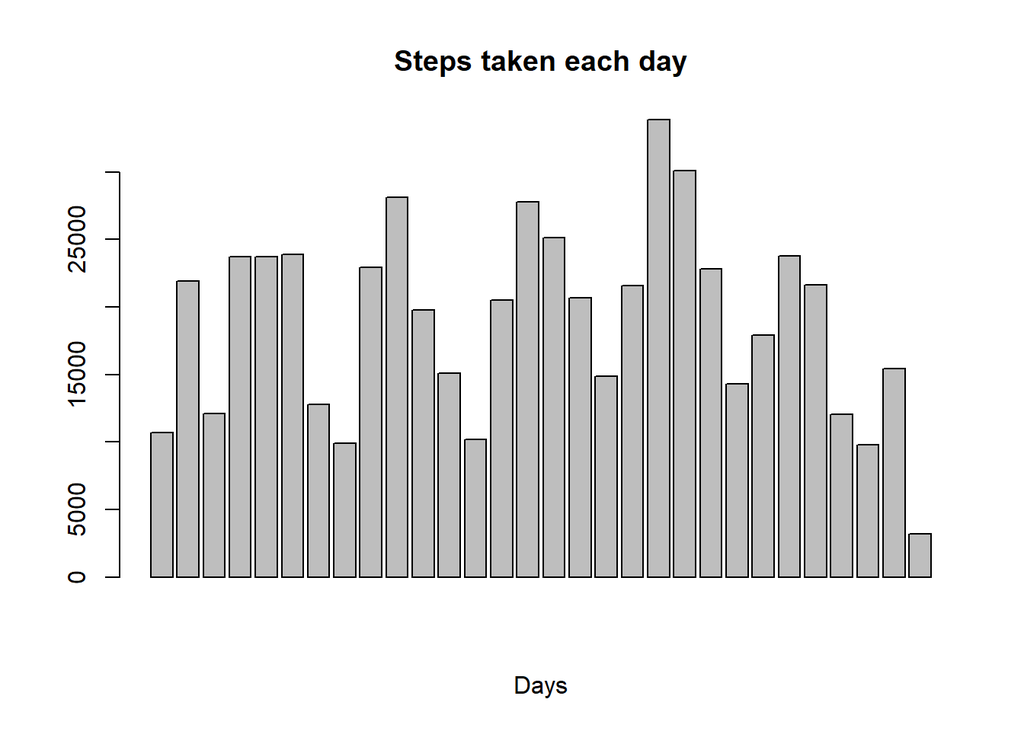

## 3. Mean and Median of each day

The mean for each day is:

```
## [1] 19020.27
```

The median fo each day is:

```
## [1] 20597.5
```

## 4. Average daily activity

The time series for Average daily activity in each interval is:

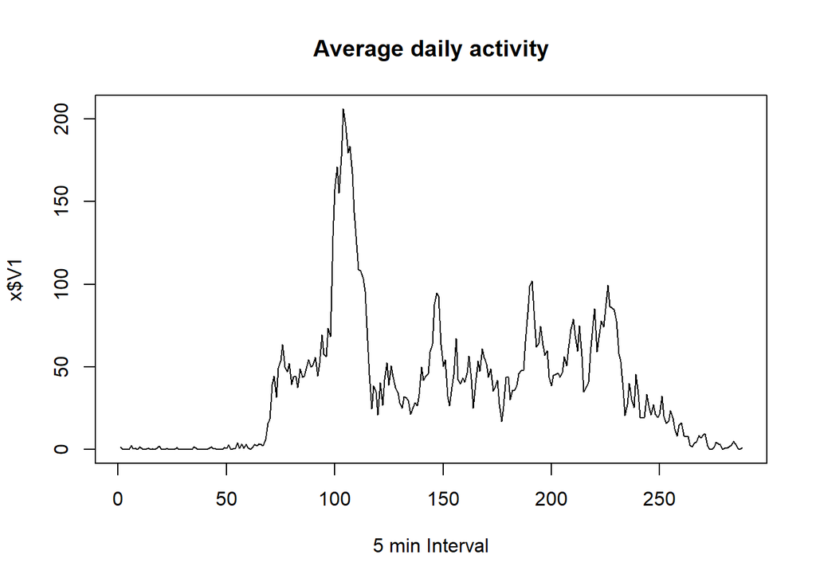

```r
x<-data[,mean(steps),by=interval]
plot(x$V1,main="Average daily activity", xlab="5 min Interval",type="l")
```

## 5. Maximum Number of Steps Interval

The interval with the maximum average steps is:

```r
max<-x[order(-x$V1),]
max[order(-max$V1),][1,1]
```

```
##    interval
## 1:      835
```

## 6. Managing Missing Data

As we can see in our previous summary we notice **there’s 2304 NA’s values in the data, specifically in the Steps variable**. The idea to fill up those empty values is first add a value that will record the number of the row where the value is missing (we will load up the “activity” file again because the previous file had no NA’s)

```r
data<-read.csv("C:/Users/Ricardo/Desktop/Coursera/Data Science Specialization/Reproducible Research/Week 2/Project/activity.csv",stringsAsFactors = F)
data<-as.data.table(data)
data$rows<-1:nrow(data)
```

Then we weill save the “date”,“interval” and “rows” variables where the NA’s is present

```r
y<-data[!complete.cases(data),c(2,3,4)]
```

In section 4 we generated the average for each interval and saved it into the “x” variable, so now we will merge those two arrays by the “interval” variable and that will asign the daily average value to the NA’s in its proper “interval” variable as follows

```r
new_array<-merge(y,x)
data[new_array$rows,1]<-new_array$V1
summary(data)
```

```
##      steps            date              interval           rows
##  Min.   :  0.00   Length:17568       Min.   :   0.0   Min.   :    1
##  1st Qu.:  0.00   Class :character   1st Qu.: 588.8   1st Qu.: 4393
##  Median :  0.00   Mode  :character   Median :1177.5   Median : 8784
##  Mean   : 37.33                      Mean   :1177.5   Mean   : 8784
##  3rd Qu.: 27.00                      3rd Qu.:1766.2   3rd Qu.:13176
##  Max.   :806.00                      Max.   :2355.0   Max.   :17568
```

## 7. New Histogram for Average daily activity

As we can see in the previous summary there’s no NA’s anymore in the “steps” variable. The changes are clear whwn we plot the **new histogram**:

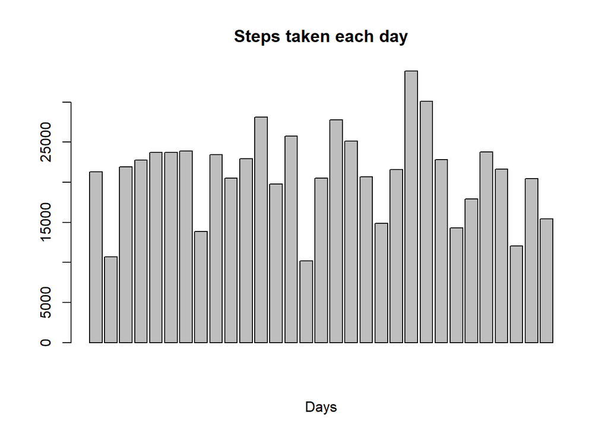

The new mean and median for each day is:

```
## [1] 21152.77
```

```
## [1] 21641
```

## 8. Weekend vs Weekday Activity

Now we want to observe the differences in the subject’s behaviour according the weekends and weekdays. For that we create a little function and use it to create a vector to define (label) if the day is a weekday or a weekend.

```r
weekdays<-sapply(data$date,function(x) {if(wday(x)<2 | wday(x)>6){"weekend"}else{"weekday"}})
data<-cbind(data,weekdays)
```

then we plot the results

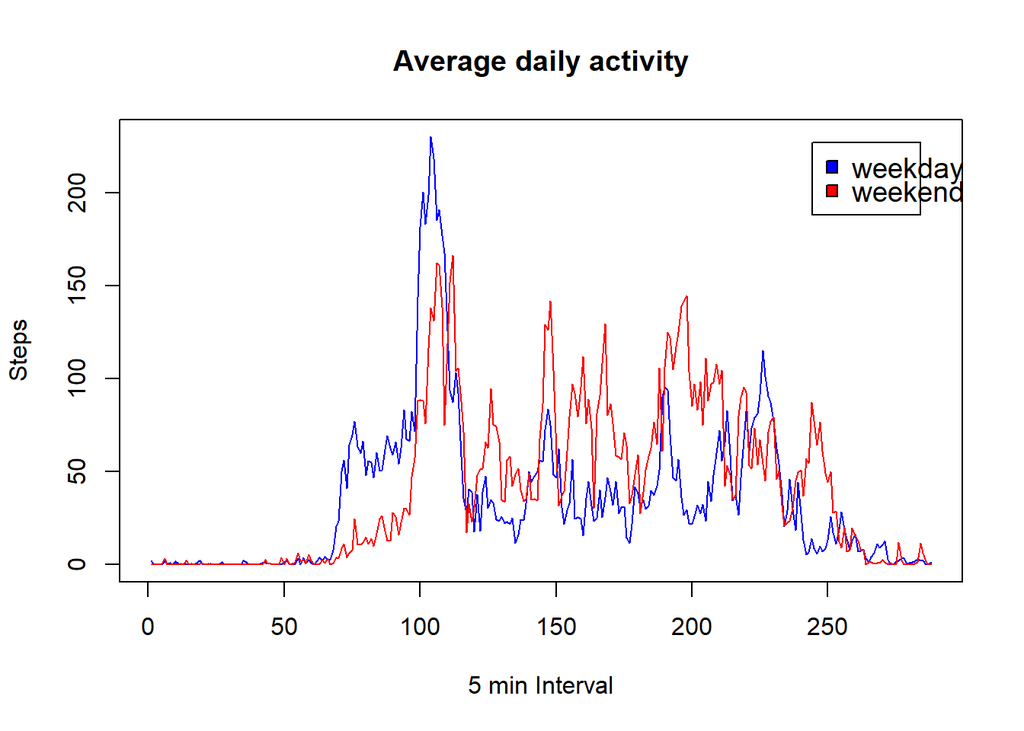

```r
data<-as.data.table(data)
wd<-data[weekdays=="weekday",mean(steps),by=interval]
we<-data[weekdays=="weekend",mean(steps),by=interval]

windows(width=15, height=8)
plot(wd$V1,main="Average daily activity", xlab="5 min Interval",ylab="Steps",type="l",col="blue")
lines(we$V1,col="red")
legend("topright", inset=.05,cex = 1.2,c("weekday","weekend"), fill=c("blue","red"))
```